# Abgabe8

Jonas Benischek

19-12-2022

#—————————————————————————— # Unbit:8 # Abgabe: 8 # Verfasser:Jonas Benischek # Beschreibung: Modelloptimierung #——————————————————————————

#### MANDANTORY: Definieren des Stammordners Ändern Sie diese Zeile NICHT

rootDIR = “C:/Datenanalyse/UsingR/Unit8/”

#### Link: https://geomoer.github.io/moer-mpg-data-analysis/unit08/unit08-03_assignment.html

### Für die Implementierung eines Kreuzvalidierungs-basierten und recht einfachen

#Tunings eines additiven Modells greifen wir auf den Datensatz der Holzernte zurück. #Ziel ist es, die Buchenernte aus der Eichenernte vorherzusagen.

#Schreiben Sie ein R-Markdown-Skript, das die Vorhersage der Buchenernte basierend #auf der Eichenernte mithilfe eines additiven Modells abstimmt. #Das Tuning sollte über die Anzahl der Knoten zwischen 3 und 13 laufen, #Und die Schätzung der Modellleistung für jeden Knoten sollte auf einer #100-fachen Kreuzvalidierung basieren, wobei 80 Prozent des Datensatzes als Training #und der Rest als Testproben verwendet werden. Die Kreuzvalidierung sollte #reproduzierbar sein. Bitte visualisieren i) der mittlere quadratische Fehler, #(ii) der mittlere quadratische Fehler +/- es ist die Standardabweichung und (iii) #das angepasste R-Quadrat als Funktion zunehmender Knoten (d. h. Knoten sollten auf #der x-Achse liegen). Da der quadratische Mittelwert viel größer ist als die #R-Quadratwerte, normalisieren Sie den quadratischen Mittelwert für die Visualisierung #auf sein Maximum.

```r
df <- read.table("/Users/Jonas/Documents/Datenanalyse/UsingR/Unit8/hessen_holzeinschlag_1997-2014.csv",
                 skip = 4, header = TRUE, sep = ";", dec = ",",encoding = "latin1")




library(mgcv)
```

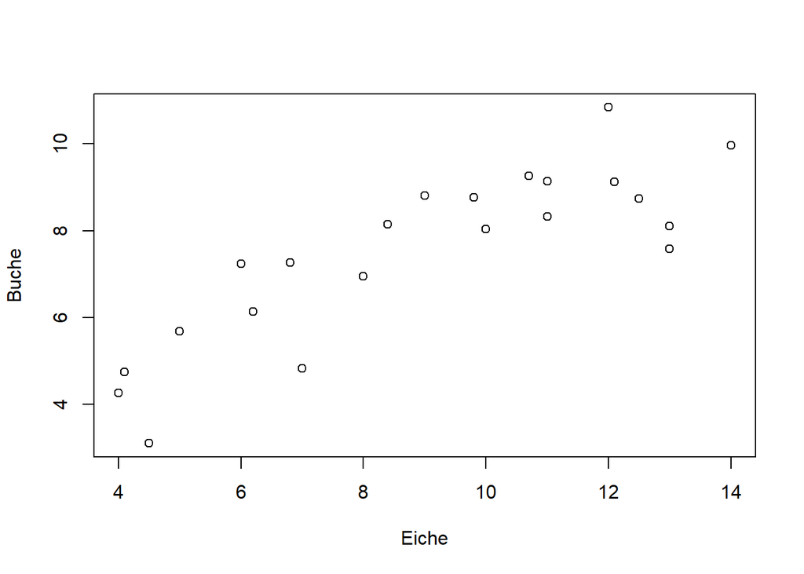

```r
Buche <- anscombe$y2
x1 <- anscombe$x1

set.seed(2)
x3 <- anscombe$x3 + sample(seq(-1, 1, 0.1), nrow(anscombe))

Buche <- c(anscombe$y1, anscombe$y2)
Eiche <- c(x1, x3)
plot(Eiche, Buche)
```

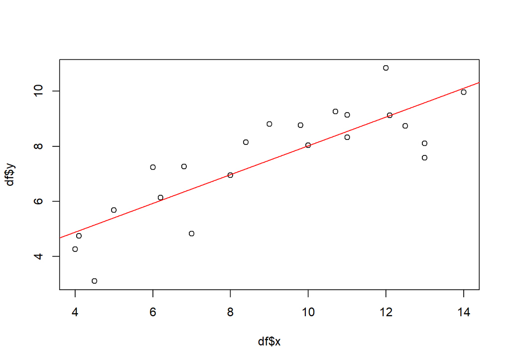

```r
############################

df <- data.frame(y = Buche,
                 x = Eiche)

############################

plot(df$x, df$y)

lmod <- lm(y ~ x, data = df)
abline(lmod, col = "red")
```

```r
############################

summary(lmod)
```

```
##
## Call:
## lm(formula = y ~ x, data = df)
##
## Residuals:
##     Min      1Q  Median      3Q     Max
## -2.0417 -0.4977  0.0128  0.8665  1.7702
##
## Coefficients:
##             Estimate Std. Error t value Pr(>|t|)
## (Intercept)  2.78483    0.71862   3.875 0.000942 ***
## x            0.52374    0.07544   6.943 9.68e-07 ***
## ---
## Signif. codes:  0 '***' 0.001 '**' 0.01 '*' 0.05 '.' 0.1 ' ' 1
##
## Residual standard error: 1.1 on 20 degrees of freedom
## Multiple R-squared:  0.7068, Adjusted R-squared:  0.6921
## F-statistic:  48.2 on 1 and 20 DF,  p-value: 9.676e-07
```

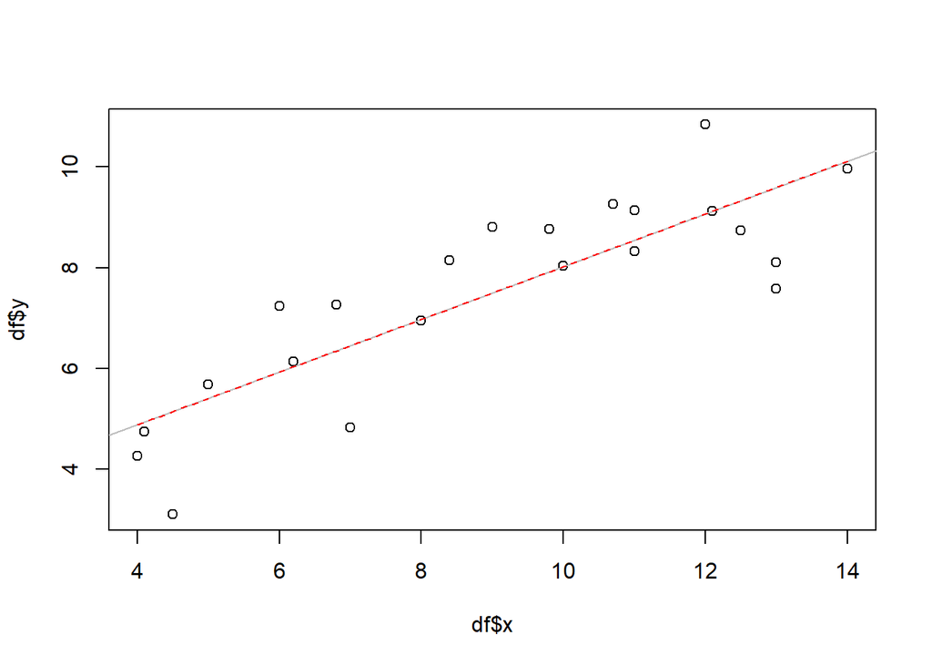

```r
# Pr(>|t|)  0.000942 ***

# p-value: 9.676e-07

####################

####################
#Die Zusammenfassung:

gammod <- gam(y ~ x, data = df, familiy = gaussian())

px <- seq(min(df$x), max(df$x), 0.1)
gampred <- predict(gammod, list(x = px))

plot(df$x, df$y)
abline(lmod, col = "grey")
lines(px, gampred, col = "red", lty=2)
```

```r
###############

summary(gammod)
```

```
##
## Family: gaussian
## Link function: identity
##
## Formula:
## y ~ x
##
## Parametric coefficients:
##             Estimate Std. Error t value Pr(>|t|)
## (Intercept)  2.78483    0.71862   3.875 0.000942 ***
## x            0.52374    0.07544   6.943 9.68e-07 ***
## ---
## Signif. codes:  0 '***' 0.001 '**' 0.01 '*' 0.05 '.' 0.1 ' ' 1
##
##
## R-sq.(adj) =  0.692   Deviance explained = 70.7%
## GCV = 1.3314  Scale est. = 1.2103    n = 22
```

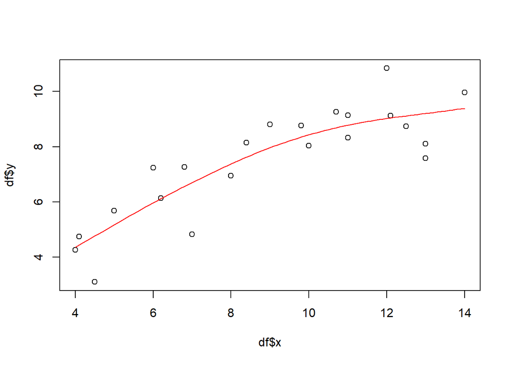

```r
#Deviance explained = 70.7%

############################


############################
#Kurve leicht gebogen

gammod <- gam(y ~ s(x, fx = FALSE), data = df)

px <- seq(min(df$x), max(df$x), 0.1)
gampred <- predict(gammod, list(x = px))

plot(df$x, df$y)
lines(px, gampred, col = "red")
```

```r
##############

summary(gammod)
```

```
##
## Family: gaussian
## Link function: identity
##
## Formula:
## y ~ s(x, fx = FALSE)
##
## Parametric coefficients:
##             Estimate Std. Error t value Pr(>|t|)
## (Intercept)   7.5009     0.2109   35.56   <2e-16 ***
## ---
## Signif. codes:  0 '***' 0.001 '**' 0.01 '*' 0.05 '.' 0.1 ' ' 1
##
## Approximate significance of smooth terms:
##        edf Ref.df     F p-value
## s(x) 2.031  2.536 25.29  <2e-16 ***
## ---
## Signif. codes:  0 '***' 0.001 '**' 0.01 '*' 0.05 '.' 0.1 ' ' 1
##
## R-sq.(adj) =  0.751   Deviance explained = 77.5%
## GCV = 1.1353  Scale est. = 0.97893   n = 22
```

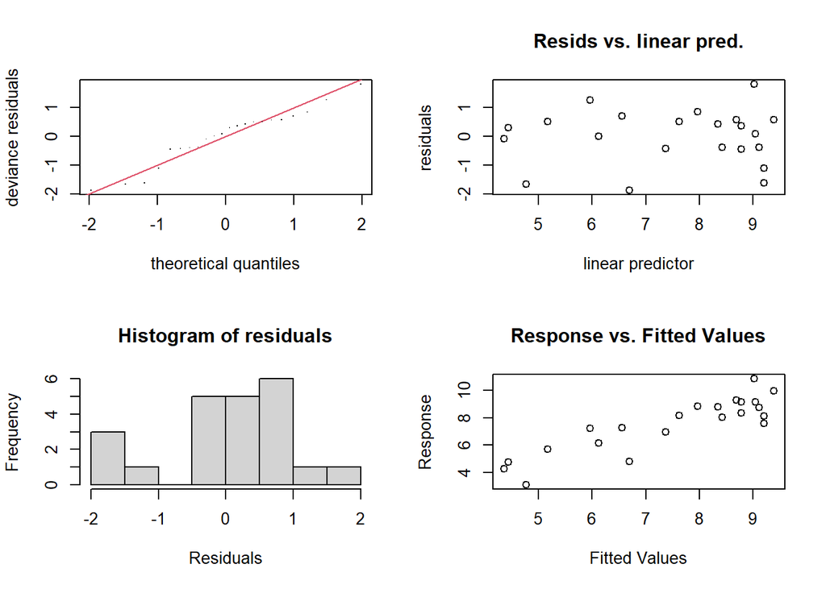

```
##
## Method: GCV   Optimizer: magic
## Smoothing parameter selection converged after 4 iterations.
## The RMS GCV score gradient at convergence was 0.0001316891 .
## The Hessian was positive definite.
## Model rank =  10 / 10
##
## Basis dimension (k) checking results. Low p-value (k-index<1) may
## indicate that k is too low, especially if edf is close to k'.
##
##        k'  edf k-index p-value
## s(x) 9.00 2.03    0.98    0.34
```

```r
# Deviance explained = 77.5%

##########################################

gam.check(gammod)
```

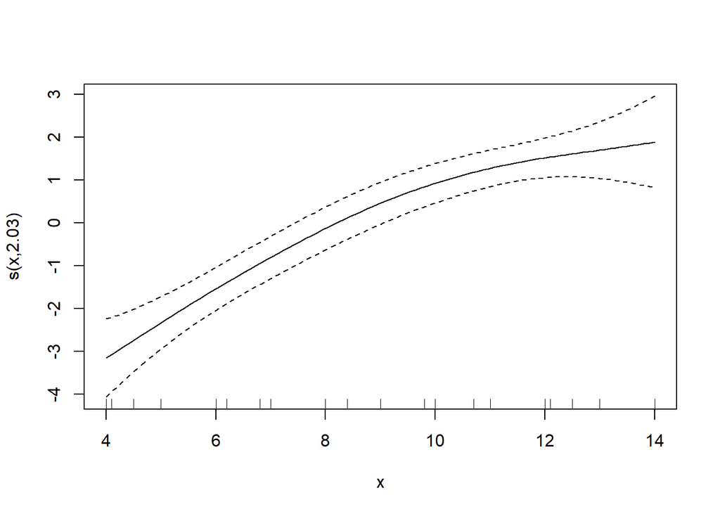

```r
##########################################

plot(gammod)
```

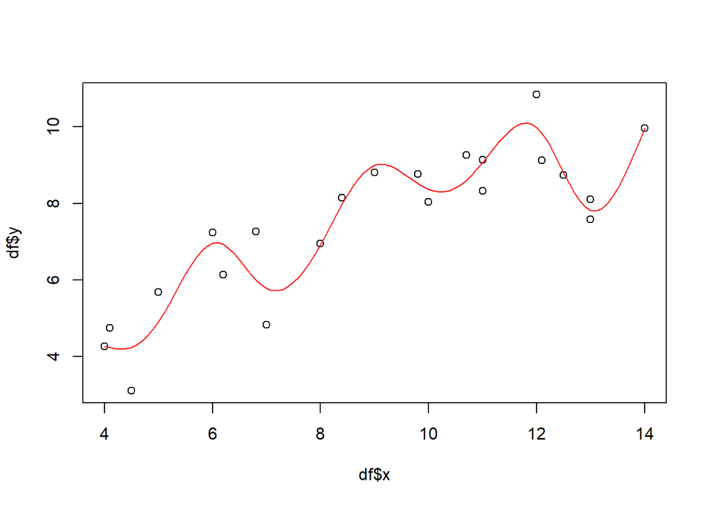

```r
#########################################

gammod <- gam(y ~ s(x, bs = "tp", fx = TRUE), data = df)

px <- seq(min(df$x), max(df$x), 0.1)
gampred <- predict(gammod, list(x = px))

plot(df$x, df$y)
lines(px, gampred, col = "red")
```

```r
################

summary(gammod)
```

```
##
## Family: gaussian
## Link function: identity
##
## Formula:
## y ~ s(x, bs = "tp", fx = TRUE)
##
## Parametric coefficients:
##             Estimate Std. Error t value Pr(>|t|)
## (Intercept)   7.5009     0.1734   43.26 1.51e-14 ***
## ---
## Signif. codes:  0 '***' 0.001 '**' 0.01 '*' 0.05 '.' 0.1 ' ' 1
##
## Approximate significance of smooth terms:
##      edf Ref.df     F  p-value
## s(x)   9      9 12.54 7.91e-05 ***
## ---
## Signif. codes:  0 '***' 0.001 '**' 0.01 '*' 0.05 '.' 0.1 ' ' 1
##
## R-sq.(adj) =  0.832   Deviance explained = 90.4%
## GCV = 1.2125  Scale est. = 0.66135   n = 22
```

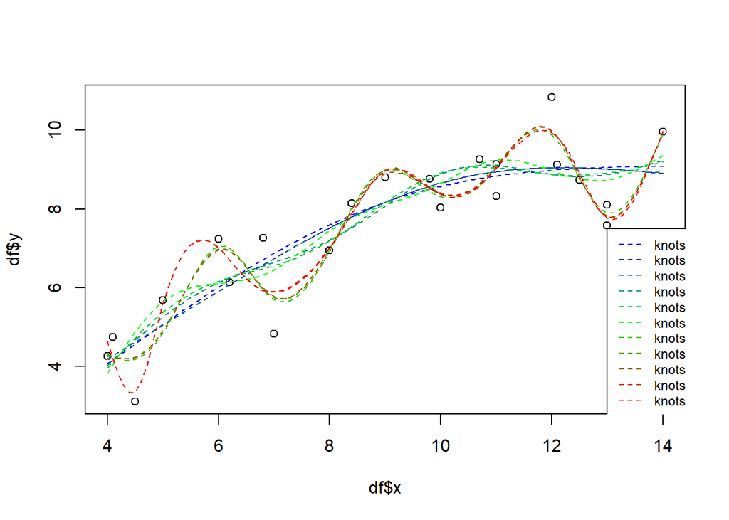

```r
#Deviance explained = 90.4%

############################

knots <- seq(3, 13)

palette <- colorRampPalette(colors=c("blue", "green", "red"))
cols <- palette(length(knots))

plot(df$x, df$y)

for(i in seq(length(knots))){
  gammod <- gam(y ~ s(x, k = knots[i], fx = TRUE), data = df)
  px <- seq(min(df$x), max(df$x), 0.1)
  gampred <- predict(gammod, list(x = px))
  lines(px, gampred, col = cols[i], lty=2)
}

legend(13, 7.5, paste("knots", knots, sep = " "), col = cols, lty=2, cex=0.75)
```

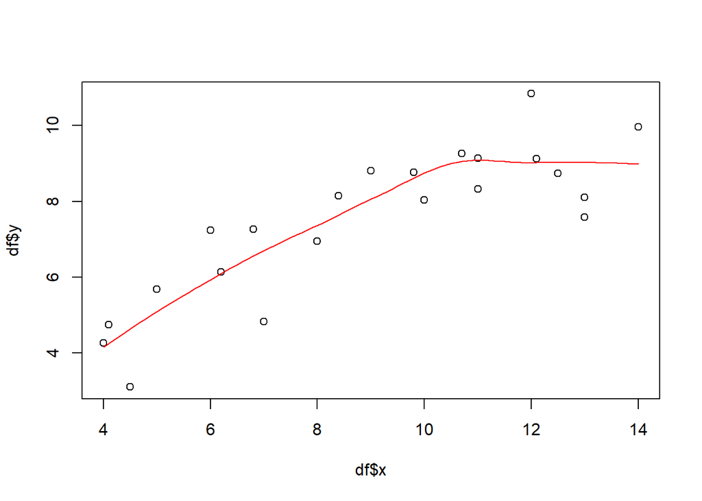

```r
##############################################################################

loessmod <- loess(y ~ x, data = df, span = 0.75)

px <- seq(min(df$x), max(df$x), 0.1)
loesspred <- predict(loessmod, data.frame(x = px), type = "response")

plot(df$x, df$y)
lines(px, loesspred, col = "red")
```

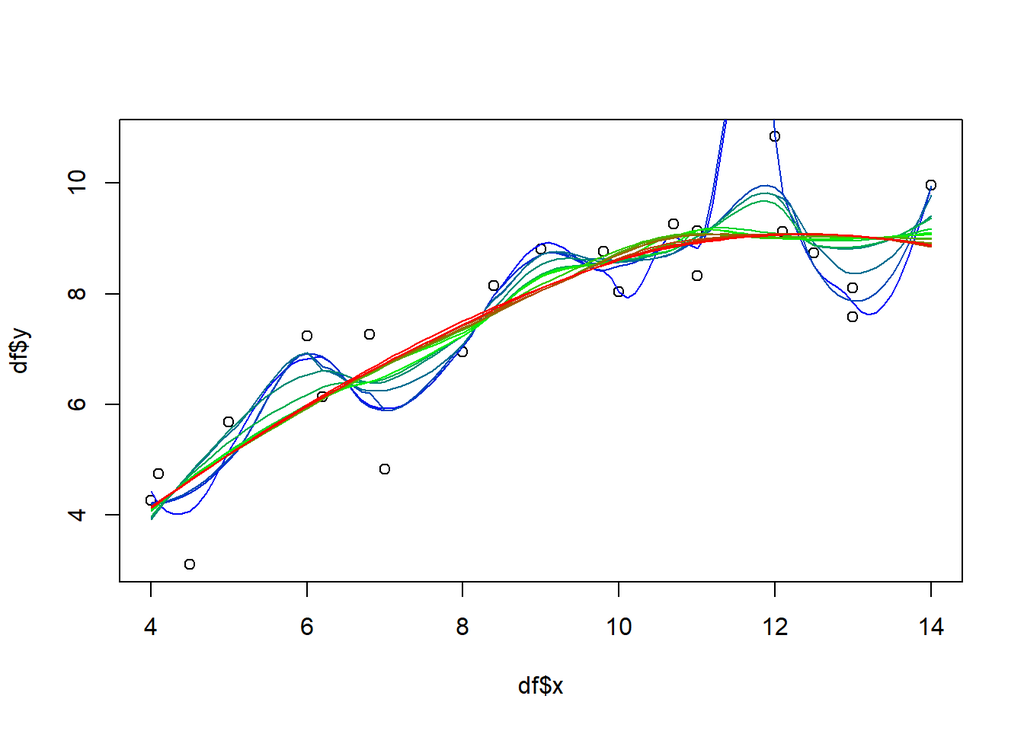

```r
#################################

window <- seq(0.3, 1, 0.01)

palette <- colorRampPalette(colors=c("blue", "green", "red"))
cols <- palette(length(window))

plot(df$x, df$y)

for(i in seq(length(window))){
  loessmod <- loess(y ~ x, data = df, span = window[i])
  px <- seq(min(df$x), max(df$x), 0.1)
  loesspred <- predict(loessmod, data.frame(x = px))
  lines(px, loesspred, col = cols[i])
}
```

[output not shown]